# K Nearest Neighbors Classifier

MDS. René Rosado González

2023-01-13

## Introduction

You will work with some data from [Chattopadhyay & Dufflo (2004)](https://www.jstor.org/stable/3598894). The results of the randomized policy experiment in India showed that women leaders tend to invest more in the provision of public goods that benefit women and children than their male counterpart. In particular you will explore if we can predict the gender of the village chiefs based on their hydric policies regarding drinking water and irrigation facilities.

Fill in the blanks in order to build a classifier using the k-nearest neighbor algorithm.

## Libraries

Load, and install if necessary, the `tidyverse` and `tidymodels` libraries. You will need to have installed the `kknn` package as well.

```r
# Install - load tidyverse
if(require(tidyverse) == FALSE){
  install.packages('tidyverse')
  library(tidyverse)
}else{
  library(tidyverse)
}
# Install - load tidymodels
if(require(tidymodels) == FALSE){
  install.packages('tidymodels')
  library(tidymodels)
}else{
  library(tidymodels)
}
# Install - kknn
if(require(kknn) == FALSE){
  install.packages('kknn')
}
```

## Dataset

Read the `india.csv` dataset and store it in an object named `india`

```r
# Load csv datasets
india = read_csv('../data/india.csv')
```

## Exploratory Data Analysis (EDA)

Perform an exploratory data analysis using the `glimpse` and `summary` functions.

```r
## Tidyway
glimpse(india)
```

```
## Rows: 322
## Columns: 4
## $ village    <chr> "GP1_village2", "GP1_village1", "GP2_village2", "GP2_villag…
## $ female     <dbl> 1, 1, 1, 1, 0, 0, 0, 0, 0, 0, 0, 0, 0, 0, 1, 1, 0, 0, 0, 0,…
## $ water      <dbl> 10, 0, 2, 31, 0, 0, 7, 12, 28, 0, 23, 12, 0, 0, 41, 23, 0, …
## $ irrigation <dbl> 0, 5, 2, 4, 0, 0, 4, 0, 0, 0, 0, 4, 0, 0, 4, 5, 0, 1, 9, 52…
```

```r
# Summary
summary(india)
```

```
##    village              female           water          irrigation
##  Length:322         Min.   :0.0000   Min.   :  0.00   Min.   : 0.000
##  Class :character   1st Qu.:0.0000   1st Qu.:  3.00   1st Qu.: 0.000
##  Mode  :character   Median :0.0000   Median :  9.00   Median : 0.000
##                     Mean   :0.3354   Mean   : 17.84   Mean   : 3.264
##                     3rd Qu.:1.0000   3rd Qu.: 20.00   3rd Qu.: 2.000
##                     Max.   :1.0000   Max.   :340.00   Max.   :90.000
```

Create a scatter plot of the `water` and `irrigation` variables, colored by `female`. Can you observe any pattern? How can we improve this visualization?

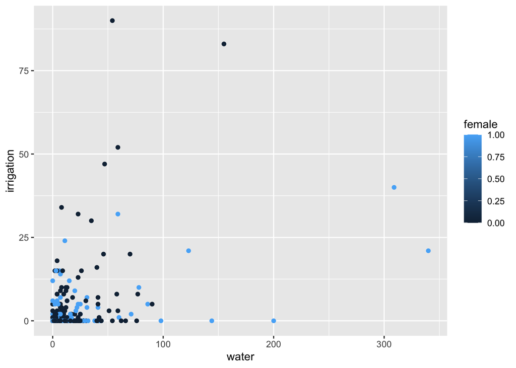

```r
# Create a ggplot object with the india dataset
ggplot(india) +
  # Add geom to create the scatter plot
  geom_point(
    # Add the water and irrigation variables on the x and y axis. Color by female
    aes(x = water, y = irrigation, color = female)
    )
```

## Data Wrangling

Create a factor variable named `politician_gender` using the `female` column. Add the labels `male` if the factor is `0`, and `female` if the factor is `1`.

```r
india = india %>%
  # Add a new column with mutate
  mutate(
    # Create a factor variable
    politician_gender = factor(
                              female,
                              levels = c(0,1),
                              labels = c('Male', 'Female')
                              )
    )
# Take a look
glimpse(india)
```

```
## Rows: 322
## Columns: 5
## $ village           <chr> "GP1_village2", "GP1_village1", "GP2_village2", "GP2…
## $ female            <dbl> 1, 1, 1, 1, 0, 0, 0, 0, 0, 0, 0, 0, 0, 0, 1, 1, 0, 0…
## $ water             <dbl> 10, 0, 2, 31, 0, 0, 7, 12, 28, 0, 23, 12, 0, 0, 41, …
## $ irrigation        <dbl> 0, 5, 2, 4, 0, 0, 4, 0, 0, 0, 0, 4, 0, 0, 4, 5, 0, 1…
## $ politician_gender <fct> Female, Female, Female, Female, Male, Male, Male, Ma…
```

Update the plot you did last time to make it a better visualization.

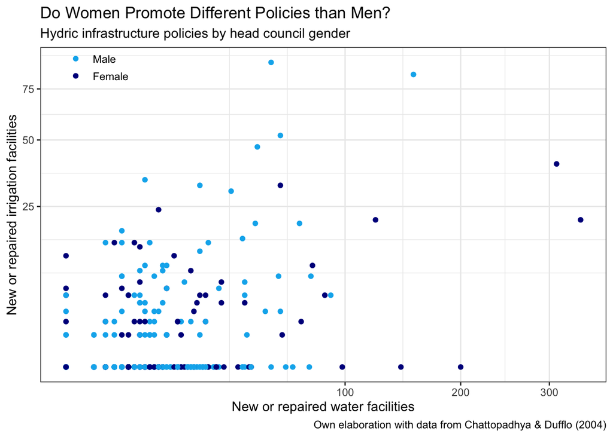

```r
# Making a better visualization
ggplot(
  # Create a ggplot object using the india dataset
  india,
  # Add the water and irrigation columns in the x and y axis.
  aes(x = water, y = irrigation)) +
  # Add geom to create the scatter plot
  geom_point(
    # Color by politician_gender
    aes(color = politician_gender)
    ) +
  # Modify the x and y axes using the scale_x_sqrt and scale_y_sqrt functions
  scale_y_sqrt() +
  scale_x_sqrt() +
  # Modify the colors to deepskyblue2 and darkblue
  scale_color_manual(values = c('deepskyblue2','darkblue')) +
  # Add proper labels
  labs(
    # Modify the x and y axis labels to make them clearer
    x = 'New or repaired water facilities',
    y = 'New or repaired irrigation facilities',
    # Add an interesting title
    title = 'Do Women Promote Different Policies than Men?',
    # Explain in a sentence what the graph is showing
    subtitle = 'Hydric infrastructure policies by head council gender',
    # Add the following caption
    caption = 'Own elaboration with data from Chattopadhya & Dufflo (2004)'
    ) +
  # Use a default theme
  theme_bw() +
  # Modify legend attributes using legend.attribute
  theme(
    # Delete legend title
    legend.title = element_blank(),
    # Delete legend background
    legend.background = element_blank(),
    # Delete legend box background
    legend.box.background = element_blank(),
    # Make legend key fill transparent
    legend.key = element_rect(fill = "transparent"),
    # Modify the legend position to de coordinates c(0.1, 0.95)
    legend.position = c(0.1, 0.95),
    # Modify the height of the legend key to 0.5 cm
    legend.key.height = unit(0.5,'cm')
  )
```

## KNN Clasifier

Create a model specification for the kkn using the `tidymodels` framework.

```r
knn_model = nearest_neighbor() %>%
  # Set the engine
  set_engine("kknn") %>%
  # Set the mode
  set_mode('classification') %>%
  # Set hyperparameters to tune
  set_args(
    neighbors = tune(),
    dist_power = tune(),
    weight_func = tune()
    )
```

Make an initial data split with 75% of the observations in the training set. To get consistent results lets set a random seed of `123`.

```r
# Data splitting for samples
set.seed(123)
india_split = initial_split(
  # Data to split
  data = india,
  # Proportions
  prop = 0.75,
  # Variable of interest
  strata = politician_gender
)

# Get training and testing samples
india_training = training(india_split)
india_testing = testing(india_split)
```

Create 3 cross validation folds from the training set.

```r
# Create cross-validation folds
set.seed(123)
india_folds = vfold_cv(india_training, v = 3)
```

Create a basic recipe to predict the `politician_gender` in fucntion of `water` and `irrigation`

```r
# Create a recipe
basic_recipe = recipe(
  # Set a formula
  formula = politician_gender ~ water + irrigation,
  # Set input data
  data = india_testing
)
```

Make a workflow object with the recipe and model you just created.

```r
# Create a workflow
knn_workflow = workflow() %>%
  # Add your recipe
  add_recipe(basic_recipe) %>%
  # Add your model
  add_model(knn_model)
```

Perform hyperparameter tuning on the workflow you just created using a `grid` of size 100.

```r
# Get parameters to tune
knn_parameters = knn_workflow %>%
  extract_parameter_set_dials()

# Create a tune grid
set.seed(123)
knn_tuning = tune_grid(
  object = knn_workflow,
  resamples = india_folds,
  param_info = knn_parameters,
  metrics = metric_set(yardstick::accuracy),
  control = control_grid(verbose = TRUE),
  grid = 100
  )
```

Collect the tuning metrics and select the best model based on the `accuracy` metric.

```r
# Collegt metrics
tuning_metrics = knn_tuning %>%
  collect_metrics() %>%
  # Arrange form higher mean to lower mean
  arrange(desc(mean))

# Select the best model
best_knn = knn_tuning %>%
  select_best("accuracy")

# Print the best model
print(best_knn)
```

```
## # A tibble: 1 × 4
##   neighbors weight_func dist_power .config
##       <int> <chr>            <dbl> <chr>
## 1        15 biweight          1.36 Preprocessor1_Model007
```

Finalize your workflow and make the last fit to collect the performance of the model with the testing sample.

```r
# Finalize the workflow with the best model
final_knn = knn_workflow %>%
  finalize_workflow(best_knn)

# Make the last fit
results_knn = final_knn %>%
  last_fit(
    split = india_split,
    metrics = metric_set(yardstick::accuracy)
    )

# Collect testing metrics
metrics_knn = results_knn %>%
  collect_metrics()

print(metrics_knn)
```

```
## # A tibble: 1 × 4
##   .metric  .estimator .estimate .config
##   <chr>    <chr>          <dbl> <chr>
## 1 accuracy binary         0.630 Preprocessor1_Model1
```

Plot the decision boundary of the model you just trained

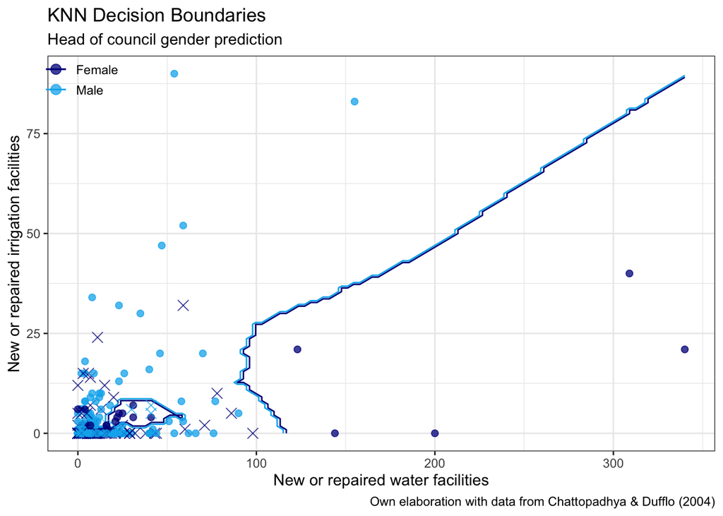

```r
# Pull the variables of interest
water = pull(india, water)
irrigation = pull(india, irrigation)

# Create the x and y range of length 100
x_range = seq(from = min(water), to = max(water), length.out = 100)
y_range = seq(from = min(irrigation), to = max(irrigation), length.out = 100)

# Create the space_grid
space_grid = expand.grid(x_range, y_range)
# Set names of the space grid
names(space_grid) = c('water', 'irrigation')

# Extract the trained model
knn_trained = results_knn %>%
  extract_fit_parsnip()

# Make the predictions
grid_prediction = augment(knn_trained, space_grid)
predictions_tb =  augment(knn_trained, india)

# Plot decision boundaries
ggplot(grid_prediction, aes(x = water, y = irrigation)) +
  # Add the contour of the Female boundary
  geom_contour(
    aes(z = as.numeric(.pred_class == 'Female'), col = 'Female'),
    breaks=c(0,1)
  ) +
  # Add the contour of the Male boundary
  geom_contour(
    aes(z = as.numeric(.pred_class == 'Male'), col = 'Male'),
    breaks=c(0,.5)
  ) +
  # Add the observations
  geom_jitter(
    data = predictions_tb,
    aes(x = water, y = irrigation,
        # Color by politician_gender
        col = politician_gender,
        # Shapey by correct prediction
        shape = (politician_gender == .pred_class)
        ),
    width = 0.01, height = 0.01, alpha = 0.75, size = 3
  ) +
  # Get rid of the shape legend
  guides(shape = 'none') +
  # Modify colors
   scale_color_manual(values = c('darkblue','deepskyblue2')) +
  # Modify shape
  scale_shape_manual(values = c(4,20)) +
  # Add proper labels
  labs(
     # Modify the x and y axis labels to make them clearer
    x = 'New or repaired water facilities',
    y = 'New or repaired irrigation facilities',
    title = 'KNN Decision Boundaries',
    subtitle = 'Head of council gender prediction',
    # Add the following caption
    caption = 'Own elaboration with data from Chattopadhya & Dufflo (2004)'
  ) +
  # Use a default theme
  theme_bw() +
  # Modify legend attributes using legend.attribute
  theme(
    legend.title = element_blank(),
    legend.background = element_blank(),
    legend.box.background = element_blank(),
    legend.key = element_rect(fill = "transparent"),
    legend.position = c(0.05, 0.95),
    legend.key.height = unit(0.5,'cm')
  )
```